# Read counts to DGE, Part I

This script will show you how to:

- Read in `featureCounts` results into R.
- Use `DESeq2` to:
- normalize read counts for sequencing depth
- transform reads to the log2 scale
- Accompany each step by exploratory plots.

You can generate an html document out of this entire script by clickling the `Knit HTML` button in RStudio.

```r
options(stringsAsFactors = FALSE) # this will change a global setting, but just for this session

library(knitr)
opts_chunk$set(echo = TRUE, message = FALSE,cache=FALSE) # tuning knitr output
```

## featureCounts

We aligned five samples for the WT and SNF2 condition, respectively. You can find those files here: `~/mat/precomputed/results_alignment`.

> How can you check which command was used to generate those `BAM` files?

```bash
## on the command line (!)
mkdir class/read_counts
cd class/read_counts
REF_DIR=~/mat/referenceGenomes/S_cerevisiae/

 # reads for yeast samples counted on the meta-feature level
~/mat/software/subread-1.6.0-Linux-x86_64/bin/featureCounts \
    -a ${REF_DIR}/Saccharomyces_cerevisiae.R64-1-1.81.gtf \
    -o featCounts_genes.txt \
     ~/mat/precomputed/results_alignment/*bam
```

Let’s read the result file into R, i.e. download the table from [our website](http://chagall.med.cornell.edu/RNASEQcourse/featureCounts_result.txt) or use the `scp` command to download the table that you generated on the server to your local machine.

Loading additional libraries:

```r
library(ggplot2) # for making plots
library(magrittr) # for "pipe"-like coding in R
```

First, make sure you set the path to your working directory which should contain the count table.

```r
folder <- "~/Documents/Teaching/2018_RNA-seq/" # download count table!
setwd(folder)
```

We will use the `DESeq2` package to normalize the samples for differences in their sequencing depth.

```r
# not available via install.packages(), but through bioconductor
source("http://bioconductor.org/biocLite.R")
biocLite("DESeq2")
```

```r
library(DESeq2)
```

We will have to generate a `DESeqDataSet`; what is needed for this can be found out via `?DESeqDataSetFromMatrix`. The help indicates that we need two tables: `countData` and `colData`.

- `colData`: `data.frame` with all the variables you know about your samples, e.g., experimental condition, the type, and date of sequencing and so on. Its row.names should correspond to the unique sample names.
- `countData`: should contain a matrix of the actual values associated with the genes and samples. Is equivalent to `assay()`. Conveniently, this is almost exactly the format of the `featureCounts` output.

```r
folder <- "~/Documents/Teaching/2018_RNA-seq/"
# reading in featureCounts output
readcounts <- read.table(paste0(folder, "featCounts_genes.txt"),
                          header=TRUE)
head(readcounts)
```

```
##      Geneid Chr Start   End Strand Length
## 1   YDL248W  IV  1802  2953      +   1152
## 2 YDL247W-A  IV  3762  3836      +     75
## 3   YDL247W  IV  5985  7814      +   1830
## 4   YDL246C  IV  8683  9756      -   1074
## 5   YDL245C  IV 11657 13360      -   1704
## 6   YDL244W  IV 16204 17226      +   1023
##   X.home.classadmin.mat.precomputed.results_alignment.SNF2_1_Aligned.sortedByCoord.out.bam
## 1                                                                                      109
## 2                                                                                        0
## 3                                                                                        6
## 4                                                                                        6
## 5                                                                                        1
## 6                                                                                       79
##   X.home.classadmin.mat.precomputed.results_alignment.SNF2_2_Aligned.sortedByCoord.out.bam
```

[output cut: 62 more lines]

**Preparing the count matrix for DESeq2:**

```r
# gene IDs should be stored as row.names
row.names(readcounts) <- gsub("-", ".", readcounts$Geneid)

# exclude the columns without read counts (columns 1 to 6 contain additional
# info such as genomic coordinates)
readcounts <- readcounts[,-c(1:6)]

# give meaningful sample names - there are many ways to achieve this
orig_names <- names(readcounts)
names(readcounts) <- c("SNF2_1", "SNF2_2", "SNF2_3", "SNF2_4", "SNF2_5",
                        "WT_1", "WT_2", "WT_3", "WT_4", "WT_5" ) # most error-prone way!

# alternatives:
names(readcounts) <- c( paste("SNF2", c(1:5), sep = "_"),
                        paste("WT", c(1:5), sep = "_") ) # less potential for typos
names(readcounts) <- gsub(".*(WT|SNF2)(_[0-9]+).*", "\\1\\2", orig_names) # why is this a safer solution?
```

Always check your data set after you manipulated it!

```r
str(readcounts)
```

```
## 'data.frame':    7126 obs. of  10 variables:
##  $ SNF2_1: int  109 0 6 6 1 79 363 41 143 2 ...
##  $ SNF2_2: int  84 1 6 6 6 59 289 22 119 4 ...
##  $ SNF2_3: int  100 1 1 1 9 49 243 26 115 1 ...
##  $ SNF2_4: int  112 0 3 4 5 60 352 26 135 5 ...
##  $ SNF2_5: int  62 3 4 4 3 37 241 22 96 3 ...
##  $ WT_1  : int  47 0 2 1 6 9 192 25 239 2 ...
##  $ WT_2  : int  65 0 3 3 2 8 169 30 343 0 ...
##  $ WT_3  : int  60 1 4 2 5 12 190 18 251 1 ...
##  $ WT_4  : int  95 0 7 4 5 30 309 42 555 3 ...
##  $ WT_5  : int  43 0 9 0 6 14 171 27 323 1 ...
```

```r
head(readcounts)
```

```
##           SNF2_1 SNF2_2 SNF2_3 SNF2_4 SNF2_5 WT_1 WT_2 WT_3 WT_4 WT_5
## YDL248W      109     84    100    112     62   47   65   60   95   43
## YDL247W.A      0      1      1      0      3    0    0    1    0    0
## YDL247W        6      6      1      3      4    2    3    4    7    9
## YDL246C        6      6      1      4      4    1    3    2    4    0
## YDL245C        1      6      9      5      3    6    2    5    5    6
## YDL244W       79     59     49     60     37    9    8   12   30   14
```

In addition to the read counts, we need some more information about the samples. According to `?colData`, this should be a `data.frame`, where the *rows* directly match the *columns* of the count data.

Here’s how this could be generated in `R` matching the `readcounts` `data.frame` we already have:

```r
sample_info <- DataFrame(condition = gsub("_[0-9]+", "", names(readcounts)),
                          row.names = names(readcounts) )
sample_info
```

```
## DataFrame with 10 rows and 1 column
##          condition
##        <character>
## SNF2_1        SNF2
## SNF2_2        SNF2
## SNF2_3        SNF2
## SNF2_4        SNF2
## SNF2_5        SNF2
## WT_1            WT
## WT_2            WT
## WT_3            WT
## WT_4            WT
## WT_5            WT
```

```r
str(sample_info)
```

```
## Formal class 'DataFrame' [package "S4Vectors"] with 6 slots
##   ..@ rownames       : chr [1:10] "SNF2_1" "SNF2_2" "SNF2_3" "SNF2_4" ...
##   ..@ nrows          : int 10
##   ..@ listData       :List of 1
##   .. ..$ condition: chr [1:10] "SNF2" "SNF2" "SNF2" "SNF2" ...
##   ..@ elementType    : chr "ANY"
##   ..@ elementMetadata: NULL
##   ..@ metadata       : list()
```

Let’s generate the `DESeqDataSet`:

```r
DESeq.ds <- DESeqDataSetFromMatrix(countData = readcounts,
                              colData = sample_info,
                              design = ~ condition)
DESeq.ds
```

```
## class: DESeqDataSet
## dim: 7126 10
## metadata(1): version
## assays(1): counts
## rownames(7126): YDL248W YDL247W.A ... RPM1 Q0297
## rowData names(0):
## colnames(10): SNF2_1 SNF2_2 ... WT_4 WT_5
## colData names(1): condition
```

```r
head(counts(DESeq.ds))
```

```
##           SNF2_1 SNF2_2 SNF2_3 SNF2_4 SNF2_5 WT_1 WT_2 WT_3 WT_4 WT_5
## YDL248W      109     84    100    112     62   47   65   60   95   43
## YDL247W.A      0      1      1      0      3    0    0    1    0    0
## YDL247W        6      6      1      3      4    2    3    4    7    9
## YDL246C        6      6      1      4      4    1    3    2    4    0
## YDL245C        1      6      9      5      3    6    2    5    5    6
## YDL244W       79     59     49     60     37    9    8   12   30   14
```

How many reads were counted for each sample ( = library sizes)?

```r
colSums(counts(DESeq.ds))
```

```
##  SNF2_1  SNF2_2  SNF2_3  SNF2_4  SNF2_5    WT_1    WT_2    WT_3    WT_4
## 9527395 8031694 8105366 9942250 6397208 5395963 7217177 5899432 9493974
##    WT_5
## 7286638
```

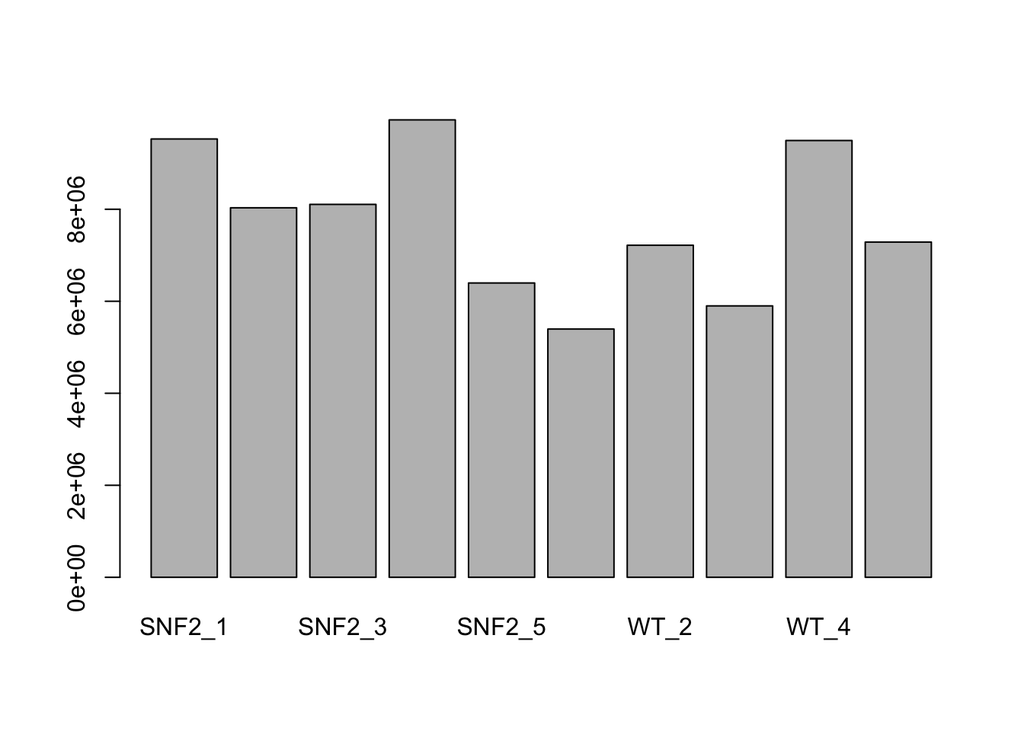

```r
colSums(counts(DESeq.ds)) %>% barplot
```

Remove genes with no reads.

```r
keep_genes <- rowSums(counts(DESeq.ds)) > 0
dim(DESeq.ds)
```

```
## [1] 7126   10
```

```r
DESeq.ds <- DESeq.ds[ keep_genes, ]
dim(DESeq.ds)
```

```
## [1] 6680   10
```

```r
counts(DESeq.ds) %>% str
```

```
##  int [1:6680, 1:10] 109 0 6 6 1 79 363 41 143 2 ...
##  - attr(*, "dimnames")=List of 2
##   ..$ : chr [1:6680] "YDL248W" "YDL247W.A" "YDL247W" "YDL246C" ...
##   ..$ : chr [1:10] "SNF2_1" "SNF2_2" "SNF2_3" "SNF2_4" ...
```

```r
assay(DESeq.ds) %>% str
```

```
##  int [1:6680, 1:10] 109 0 6 6 1 79 363 41 143 2 ...
##  - attr(*, "dimnames")=List of 2
##   ..$ : chr [1:6680] "YDL248W" "YDL247W.A" "YDL247W" "YDL246C" ...
##   ..$ : chr [1:10] "SNF2_1" "SNF2_2" "SNF2_3" "SNF2_4" ...
```

Now that we have the data, we can start using `DESeq`’s functions, e.g. `estimateSizeFactors()` for sequencing depth normalization.

```r
DESeq.ds <- estimateSizeFactors(DESeq.ds)
sizeFactors(DESeq.ds)
```

```
##    SNF2_1    SNF2_2    SNF2_3    SNF2_4    SNF2_5      WT_1      WT_2
## 1.4257668 1.1065006 1.0991960 1.4790643 0.8925667 0.5991287 0.9459106
##      WT_3      WT_4      WT_5
## 0.7697230 1.1385141 0.9026871
```

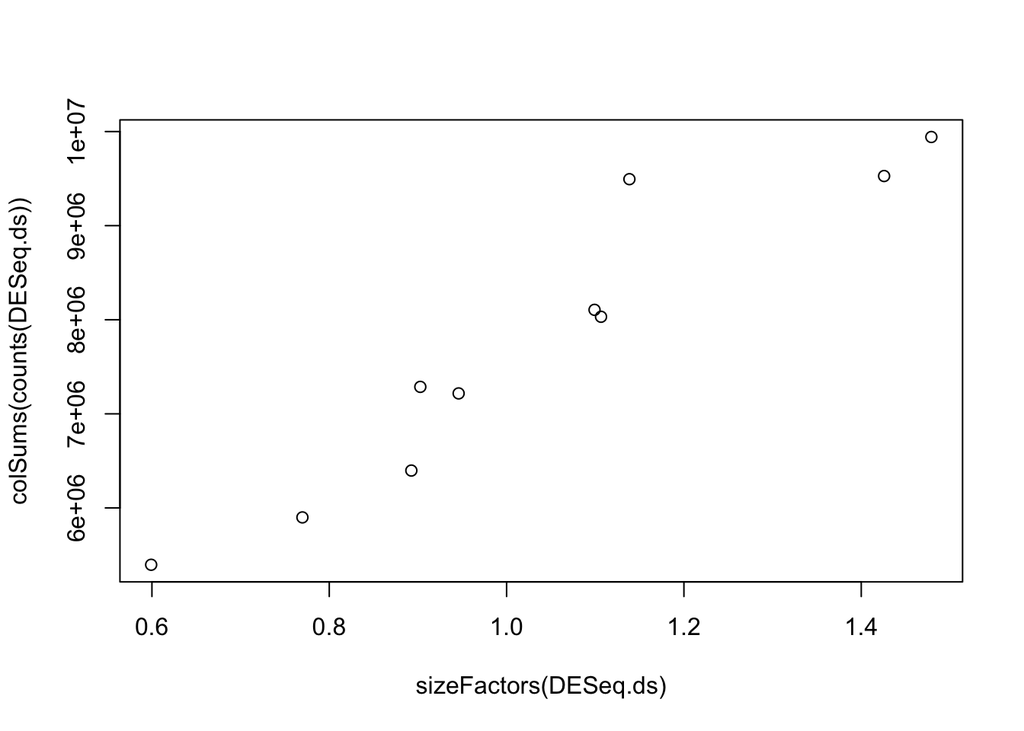

```r
plot(sizeFactors(DESeq.ds), colSums(counts(DESeq.ds)))
```

The read counts normalized for sequencing depth can be accessed via `counts(..., normalized = TRUE)`.

Let’s check whether the normalization helped adjust global differences between the samples.

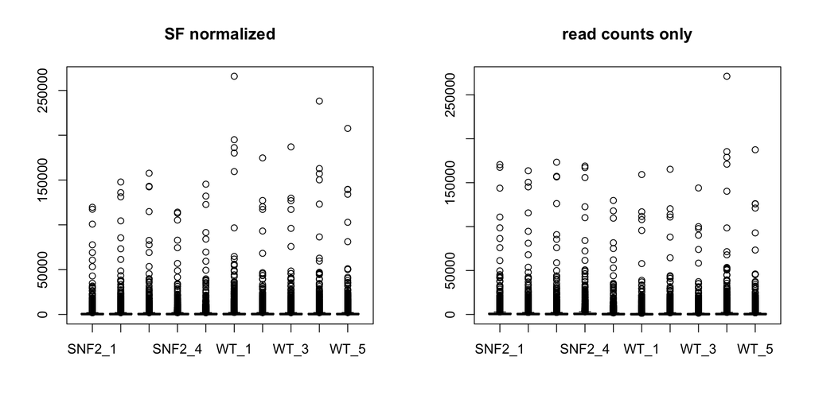

```r
# setting up the plotting layout
par(mfrow=c(1,2))
counts.sf_normalized <- counts(DESeq.ds, normalized=TRUE)

# adding the boxplots
boxplot(counts.sf_normalized, main = "SF normalized")
boxplot(counts(DESeq.ds), main = "read counts only")
```

We can’t really see anything. It is usually helpful to *transform* the normalized read counts to bring them onto more similar scales.

> To see the influence of the sequencing depth normalization, make two box plots of log2(read counts) - one for unnormalized counts, the other one for normalized counts (exclude genes with zero reads in all samples).

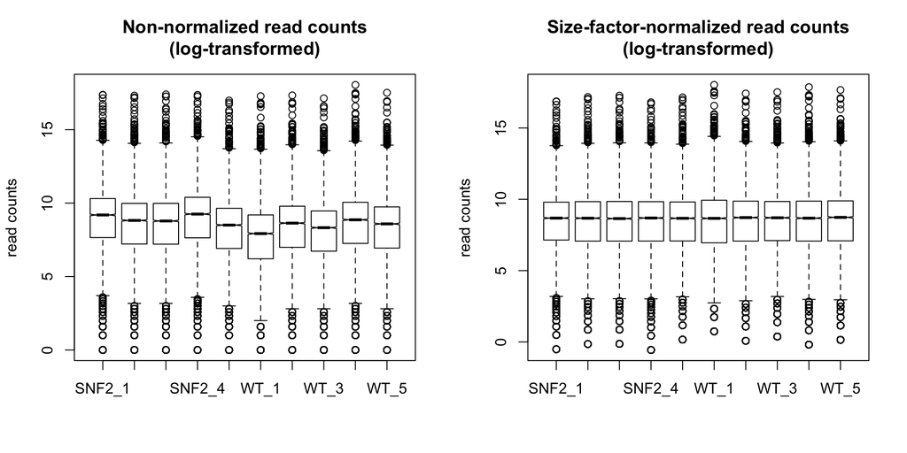

```r
par(mfrow=c(1,2)) # to plot the two box plots next to each other
boxplot(log2(counts(DESeq.ds)), notch=TRUE,
        main = "Non-normalized read counts\n(log-transformed)",
        ylab="read counts")
boxplot(log2(counts(DESeq.ds, normalize= TRUE)), notch=TRUE,
        main = "Size-factor-normalized read counts\n(log-transformed)",
        ylab="read counts")
```

### Understanding more properties of read count data

Characteristics we’ve touched upon so far:

- zeros can mean two things: no expression or no detection
- fairly large dynamic range

> Make a scatterplot of log normalized counts against each other to see how well the actual values correlate which each other per sample and gene.

```r
load("~/Documents/Teaching/2018_RNA-seq/Rclass.RData")
library(magrittr)
library(ggplot2)
library(DESeq2)
```

```r
# non-normalized read counts plus pseudocount
log.counts <- log2(counts(DESeq.ds, normalized = FALSE) + 1)
# instead of creating a new object, we could assign the values to a distinct matrix
# within the DESeq.ds object
assay(DESeq.ds, "log.counts") <- log.counts
# normalized read counts
log.norm.counts <- log2(counts(DESeq.ds, normalized=TRUE) + 1)
assay(DESeq.ds, "log.norm.counts") <- log.norm.counts
```

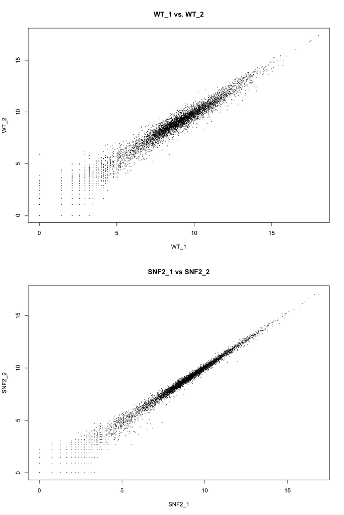

```r
par(mfrow=c(2,1))
DESeq.ds[, c("WT_1","WT_2")] %>% assay(.,  "log.norm.counts") %>% plot(., cex=.1, main = "WT_1 vs. WT_2")
DESeq.ds[, c("SNF2_1","SNF2_2")] %>% assay(.,  "log.norm.counts") %>% plot(., cex=.1, main = "SNF2_1 vs SNF2_2")
```

Every dot = one gene.

The fanning out of the points in the lower left corner (points below $2^5 = 32$) indicates that read counts correlate less well between replicates when they are low.

This observation indicates that the standard deviation of the expression levels may depend on the mean: the lower the mean read counts per gene, the higher the standard deviation.

This can be assessed visually; the package `vsn` offers a simple function for this.

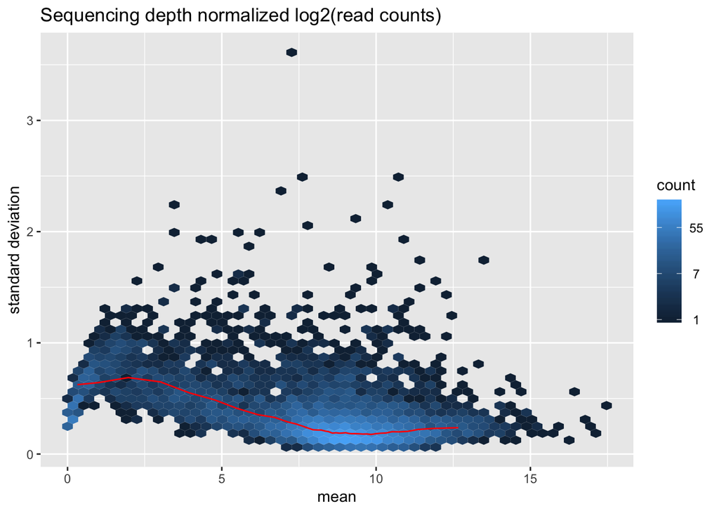

```r
par(mfrow=c(1,1))
# generate the base meanSdPlot using sequencing depth normalized log2(read counts)
log.norm.counts <- log2(counts(DESeq.ds, normalized=TRUE) + 1)
msd_plot <- vsn::meanSdPlot(log.norm.counts,
                       ranks=FALSE, # show the data on the original scale
                       plot = FALSE)
msd_plot$gg +
  ggtitle("Sequencing depth normalized log2(read counts)") +
  ylab("standard deviation")
```

From the help for`meanSdPlot`: *The red dots depict the running median estimator* *(window-width 10 percent). If there is no variance-mean dependence, then the line* *formed by the red dots should be approximately horizontal.*

The plot here shows that there is some variance-mean dependence for genes with low read counts. This means that the data shows signs of *heteroskedasticity*.

Many tools expect data to be *homoskedastic*, i.e., all variables should have similar variances.

DESeq offers two ways to shrink the log-transformed counts for genes with very low counts: `rlog` and `varianceStabilizingTransformation` (`vst`).

We’ll use `rlog` here as it is an optimized method for RNA-seq read counts: it transforms the read counts to the log2 scale while simultaneously minimizing the difference between samples for rows with small counts and taking differences between library sizes of the samples into account. `vst` tends to depend a bit more on the size factors, but generally, both methods should return similar results.

```r
DESeq.rlog <- rlog(DESeq.ds, blind = TRUE) # this actually generates a different type of object
# set blind = FALSE if the conditions
# are expected to introduce strong differences in a large proportion of the genes
```

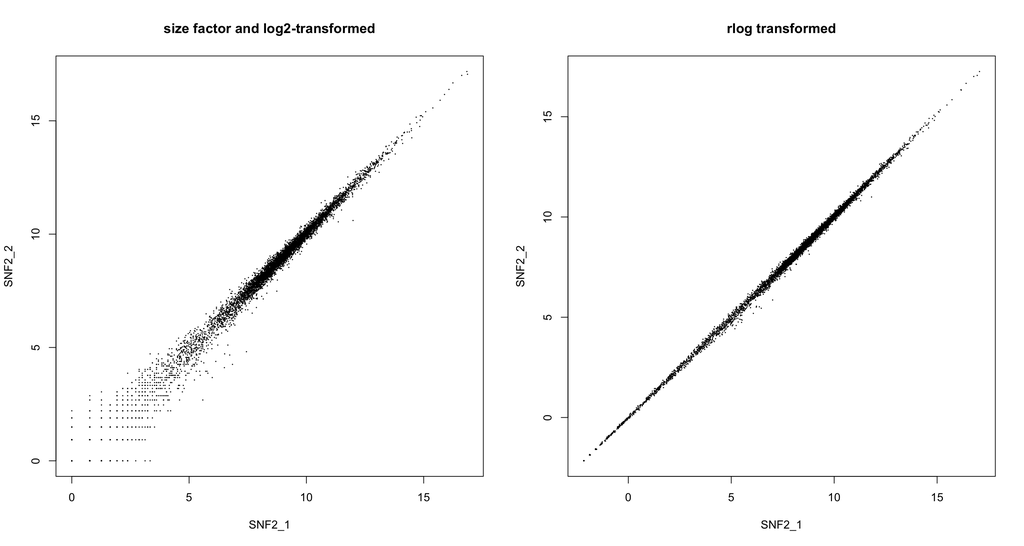

```r
par(mfrow=c(1,2))
plot(log.norm.counts[,1:2], cex=.1,
     main = "size factor and log2-transformed")

# the rlog-transformed counts are stored in the accessor "assay"
plot(assay(DESeq.rlog)[,1],
     assay(DESeq.rlog)[,2],
     cex=.1, main = "rlog transformed",
     xlab = colnames(assay(DESeq.rlog[,1])),
     ylab = colnames(assay(DESeq.rlog[,2])) )
```

```r
rlog.norm.counts <- assay(DESeq.rlog)
```

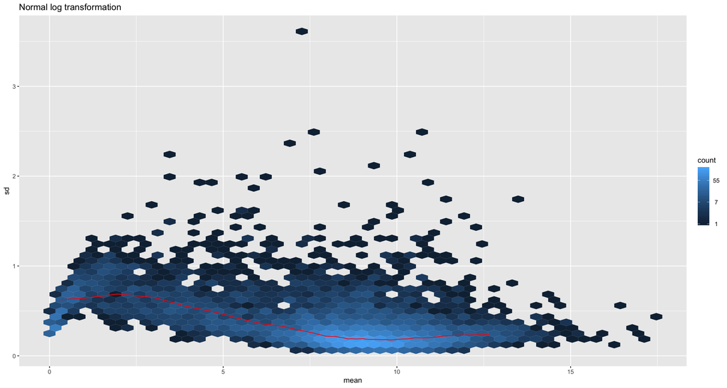

```r
# sequencing depth normalized log2(read counts)
msd_plot <- vsn::meanSdPlot(log.norm.counts, ranks=FALSE, plot = FALSE)
msd_plot$gg + ggtitle("Normal log transformation")
```

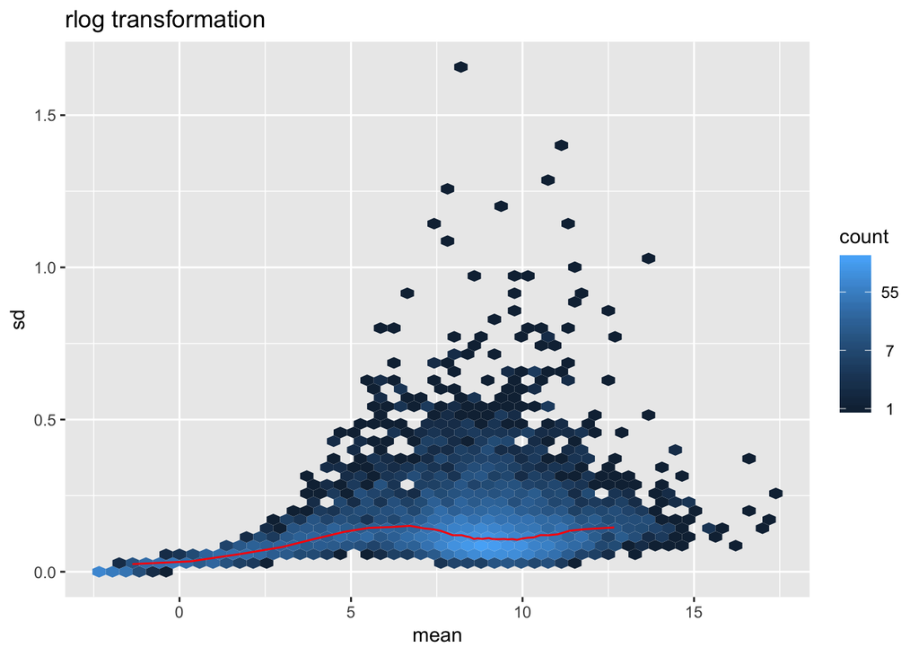

```r
# rlog-transformed read counts
msd_plot <- vsn::meanSdPlot( rlog.norm.counts, ranks=FALSE, plot = FALSE)
msd_plot$gg + ggtitle("rlog transformation")
```

```r
save.image(file = "~/Documents/Teaching/2018_RNA-seq/Rclass.RData")
```

### Similarity assessments and clustering

`pcaExplorer` lets you interact with the DESeq2-based plots and analyses. It has included hierarchical clustering of samples and PCA.

#### `pcaExplorer`

```r
#source("https://bioconductor.org/biocLite.R")
#biocLite("pcaExplorer")
pcaExplorer::pcaExplorer(dds = DESeq.ds, rlt = DESeq.rlog)
```

#### Sample clustering using Pearson correlation

The ENCODE consortium recommends that *“for messenger RNA, (…) biological replicates [should] display greater than 0.9 correlation for transcripts/features”*.

The Pearson correlation coefficient is a measure of the strength of the linear relationship between two variables and is often used to assess the similarity of RNA-seq samples in a pair-wise fashion. It is defined as the **covariance of two variables divided by the product of their standard deviation**.

Mimicking `pcaExplorer`’s heatmap:

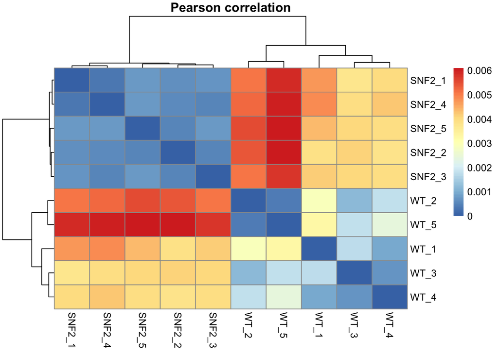

```r
corr_coeff <- cor(rlog.norm.counts, method = "pearson")
as.dist(1-corr_coeff, upper = TRUE) %>%as.matrix %>% pheatmap::pheatmap(., main = "Pearson correlation")
```

Just plot the dendrogram, comparing the effects of the `rlog` transformation.

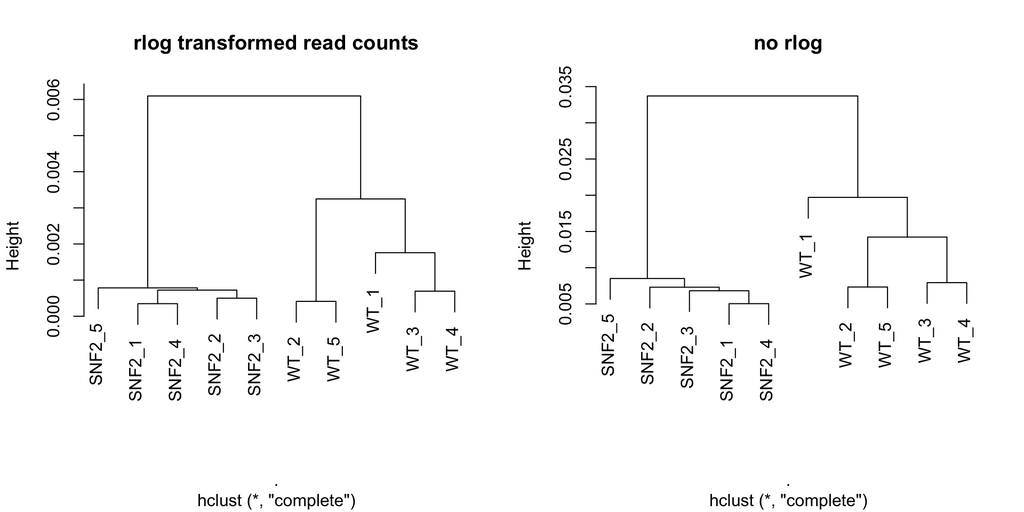

```r
par(mfrow=c(1,2))
# Pearson corr. for rlog.norm values
as.dist(1 - corr_coeff) %>% hclust %>% plot( ., labels = colnames(rlog.norm.counts), main = "rlog transformed read counts")

# Pearson corr. for log.norm.values
as.dist( 1 - cor(log.norm.counts, method = "pearson")) %>% hclust %>% plot( ., labels = colnames(log.norm.counts), main = "no rlog")
```

#### How to do the PCA yourself (see the “protocol” part of pcaExplorer!)

```r
rv <- rowVars(assay(DESeq.rlog)) # equivalent to rowVars(rlog.norm.counts)
top_variable <- order(rv, decreasing = TRUE)[seq_len(500)]
pca <- prcomp(t(assay(DESeq.rlog)[top_variable, ]))
head(pca$x)
```